# ISLR - Chapter 4 - Lab

Saad M. Siddiqui

3/8/2022

# Example 01 - Stock Market Data - Logistic Regression

## Initial Exploration

```r
# `Smarket` is a dataset of stock market returns on the S&P 500 index.
# It has the percentage returns for each of the five previous trading days `Lag1` to `Lag5`
# It also has `Volume` - the number of shares traded on the previous day
# The target is `Direction` - whether the market was `Up` or `Down` on the current date
names(Smarket)
```

```
## [1] "Year"      "Lag1"      "Lag2"      "Lag3"      "Lag4"      "Lag5"
## [7] "Volume"    "Today"     "Direction"
```

```r
dim(Smarket)      # 1250 rows, 9 columns
```

```
## [1] 1250    9
```

```r
summary(Smarket)
```

```
##       Year           Lag1                Lag2                Lag3
##  Min.   :2001   Min.   :-4.922000   Min.   :-4.922000   Min.   :-4.922000
##  1st Qu.:2002   1st Qu.:-0.639500   1st Qu.:-0.639500   1st Qu.:-0.640000
##  Median :2003   Median : 0.039000   Median : 0.039000   Median : 0.038500
##  Mean   :2003   Mean   : 0.003834   Mean   : 0.003919   Mean   : 0.001716
##  3rd Qu.:2004   3rd Qu.: 0.596750   3rd Qu.: 0.596750   3rd Qu.: 0.596750
##  Max.   :2005   Max.   : 5.733000   Max.   : 5.733000   Max.   : 5.733000
##       Lag4                Lag5              Volume           Today
##  Min.   :-4.922000   Min.   :-4.92200   Min.   :0.3561   Min.   :-4.922000
##  1st Qu.:-0.640000   1st Qu.:-0.64000   1st Qu.:1.2574   1st Qu.:-0.639500
##  Median : 0.038500   Median : 0.03850   Median :1.4229   Median : 0.038500
##  Mean   : 0.001636   Mean   : 0.00561   Mean   :1.4783   Mean   : 0.003138
##  3rd Qu.: 0.596750   3rd Qu.: 0.59700   3rd Qu.:1.6417   3rd Qu.: 0.596750
##  Max.   : 5.733000   Max.   : 5.73300   Max.   :3.1525   Max.   : 5.733000
##  Direction
##  Down:602
##  Up  :648
##
##
##
##
```

The `cor` function produces a matrix of pairwise correlations in the dataset.

```r
round(cor(Smarket[, -9]), 3)    # All columns except for Target, since we need numeric cols
```

```
##         Year   Lag1   Lag2   Lag3   Lag4   Lag5 Volume  Today
## Year   1.000  0.030  0.031  0.033  0.036  0.030  0.539  0.030
## Lag1   0.030  1.000 -0.026 -0.011 -0.003 -0.006  0.041 -0.026
## Lag2   0.031 -0.026  1.000 -0.026 -0.011 -0.004 -0.043 -0.010
## Lag3   0.033 -0.011 -0.026  1.000 -0.024 -0.019 -0.042 -0.002
## Lag4   0.036 -0.003 -0.011 -0.024  1.000 -0.027 -0.048 -0.007
## Lag5   0.030 -0.006 -0.004 -0.019 -0.027  1.000 -0.022 -0.035
## Volume 0.539  0.041 -0.043 -0.042 -0.048 -0.022  1.000  0.015
## Today  0.030 -0.026 -0.010 -0.002 -0.007 -0.035  0.015  1.000
```

There is practically no correlation between today’s returns and the percentage changes of the last 5 days or last 5 days’ returns. The only real correlation is between the `Year` and `Volume`, which suggests volume of shares traded increases with year.

```r
# Data is ordered chronologically
head(Smarket)
```

```
##   Year   Lag1   Lag2   Lag3   Lag4   Lag5 Volume  Today Direction
## 1 2001  0.381 -0.192 -2.624 -1.055  5.010 1.1913  0.959        Up
## 2 2001  0.959  0.381 -0.192 -2.624 -1.055 1.2965  1.032        Up
## 3 2001  1.032  0.959  0.381 -0.192 -2.624 1.4112 -0.623      Down
## 4 2001 -0.623  1.032  0.959  0.381 -0.192 1.2760  0.614        Up
## 5 2001  0.614 -0.623  1.032  0.959  0.381 1.2057  0.213        Up
## 6 2001  0.213  0.614 -0.623  1.032  0.959 1.3491  1.392        Up
```

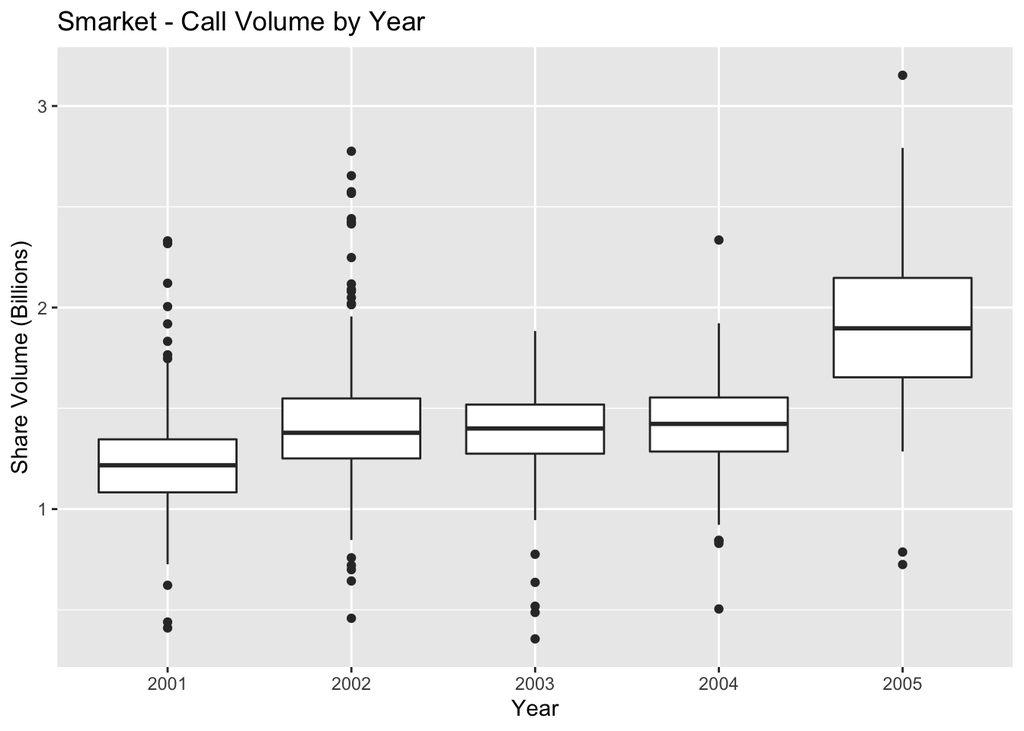

```r
# There is an increase in volume with year
ggplot(data = Smarket, aes(x = factor(Year), y = Volume)) +
  geom_boxplot() +
  labs(x = 'Year', y = 'Share Volume (Billions)', title = 'Smarket - Call Volume by Year')
```

## Logistic Regression - All Variables

We will fit a logistic regression model to predict `Directon` using `Lag1` - `Lag5` and `Volume` as predictors.

We use `family = binomial` as an argument to the `glm` function to do so.

```r
glm.fits.logreg <- glm(
  Direction ~ Lag1 + Lag2 + Lag3 + Lag4 + Lag5 + Volume,
  data = Smarket,
  family = binomial
)
summary(glm.fits.logreg)
```

```
##
## Call:
## glm(formula = Direction ~ Lag1 + Lag2 + Lag3 + Lag4 + Lag5 +
##     Volume, family = binomial, data = Smarket)
##
## Deviance Residuals:
##    Min      1Q  Median      3Q     Max
## -1.446  -1.203   1.065   1.145   1.326
##
## Coefficients:
##              Estimate Std. Error z value Pr(>|z|)
## (Intercept) -0.126000   0.240736  -0.523    0.601
## Lag1        -0.073074   0.050167  -1.457    0.145
## Lag2        -0.042301   0.050086  -0.845    0.398
## Lag3         0.011085   0.049939   0.222    0.824
## Lag4         0.009359   0.049974   0.187    0.851
## Lag5         0.010313   0.049511   0.208    0.835
## Volume       0.135441   0.158360   0.855    0.392
##
## (Dispersion parameter for binomial family taken to be 1)
##
##     Null deviance: 1731.2  on 1249  degrees of freedom
## Residual deviance: 1727.6  on 1243  degrees of freedom
## AIC: 1741.6
##
## Number of Fisher Scoring iterations: 3
```

The smallest `p`- value associated with a predictor in this model is 0.145 with `Lag1`, but even this is well above the 0.05 threshold usually used for significance. So there is no clear evidence of association between any `Lag` predictor and the response.

Generally, the coefficients are telling us that if the percentage change was positive yesterday or the day before yesterday, then the market is likely to go `Down` today.

We use the `coef` function to access the coefficients for this model, or subset using the object returned by `summary`.

```r
# What were the coefficients?
coef(glm.fits.logreg)
```

```
##  (Intercept)         Lag1         Lag2         Lag3         Lag4         Lag5
## -0.126000257 -0.073073746 -0.042301344  0.011085108  0.009358938  0.010313068
##       Volume
##  0.135440659
```

```r
# Another way of accessing same information
summary(glm.fits.logreg)$coef
```

```
##                 Estimate Std. Error    z value  Pr(>|z|)
## (Intercept) -0.126000257 0.24073574 -0.5233966 0.6006983
## Lag1        -0.073073746 0.05016739 -1.4565986 0.1452272
## Lag2        -0.042301344 0.05008605 -0.8445733 0.3983491
## Lag3         0.011085108 0.04993854  0.2219750 0.8243333
## Lag4         0.009358938 0.04997413  0.1872757 0.8514445
## Lag5         0.010313068 0.04951146  0.2082966 0.8349974
## Volume       0.135440659 0.15835970  0.8552723 0.3924004
```

The `predict` function can be used to predict the probability of the response belonging to the positive class. With `type = 'response'` argument, `R` outputs probabilities of the form $P(Y = 1 | X)$ as opposed to the other information such as the logit.

In this case, we know the positive class corresponds to the market going up because of the `contrasts` object which as been created.

```r
glm.probs.logreg <- predict(glm.fits.logreg, type = 'response')
glm.probs.logreg[1:10]     # First 10 probabilities
```

```
##         1         2         3         4         5         6         7         8
## 0.5070841 0.4814679 0.4811388 0.5152224 0.5107812 0.5069565 0.4926509 0.5092292
##         9        10
## 0.5176135 0.4888378
```

```r
# How are the response variables encoded?
contrasts(Smarket$Direction)
```

```
##      Up
## Down  0
## Up    1
```

In order to binomialize the predicted probabilities, we need to compare them with a threshold value like 0.5 and conver them into a class label.

```r
# Initialize a vector of predicted classes that is `Down` by default
glm.pred.logreg <- rep('Down', length(glm.probs.logreg))

# Convert the elements where the probability is higher than a threshold to `Up`
glm.pred.logreg[glm.probs.logreg > 0.5] <- 'Up'

# Use the `table` function to check what proportion falls into each category
table(glm.pred.logreg, Smarket$Direction) # Simlar to confusion matrix
```

```
##
## glm.pred.logreg Down  Up
##            Down  145 141
##            Up    457 507
```

```r
# Accuracy - What proportion of predictions were correct?
# (TP + TN) / (TP + FP + TN + FN)
mean(glm.pred.logreg == Smarket$Direction)
```

```
## [1] 0.5216
```

### Logistic Regression - Train/Validation Split

This is not a great model because the **training** error rate is $100% - 52.2% = 47.8%$. This is the error rate on data that has been used to train the model itself. This is to be expected since the $p$-values associated with the predictors offered no proof of statistically significant association between the predictors and the response.

A better way of assessing model performance is to compute metrics of interest on a **validation** or **held out** data set.

To do this, we will use 2001 - 2004’s data for training and validate on 2005’s data.

```r
train.idx <- (Smarket$Year < 2005)
Smarket.2005 <- Smarket[!train.idx, ]
dim(Smarket.2005)
```

```
## [1] 252   9
```

```r
Direction.2005 <- Smarket$Direction[!train.idx]
```

We now fit a logistic regression model using only the training data and validate on the test data.

```r
# Train the model on Smarket data which is subsetted based on `train.idx`
glm.fits.logreg <- glm(
  Direction ~ Lag1 + Lag2 + Lag3 + Lag4 + Lag5 + Volume,
  data = Smarket,
  family = binomial,
  subset = train.idx
)

# Get probabilities for each data point in 2005 - this was not used for training
glm.probs.logreg <- predict(glm.fits.logreg, Smarket.2005, type = 'response')

# Make a vector to store class labels based on binomialized probabilities
glm.pred.logreg <- rep('Down', 252)
glm.pred.logreg[glm.probs.logreg > 0.5] <- 'Up'
table(glm.pred.logreg, Direction.2005)
```

```
##                Direction.2005
## glm.pred.logreg Down Up
##            Down   77 97
##            Up     34 44
```

```r
# Check accuracy and error rate
mean(glm.pred.logreg == Direction.2005)
```

```
## [1] 0.4801587
```

```r
mean(glm.pred.logreg != Direction.2005)
```

```
## [1] 0.5198413
```

Test error rate is ~52%, which is worse than random guessing. This is not surprising considering that it is very difficult to predict the directon of movement of the stock market.

### Logistic Regression - Fewer Variables

```r
# Fit the model with fewer variables
glm.fits.logreg.simple <- glm(Direction ~ Lag1 + Lag2,
                              data = Smarket,
                              family = binomial,
                              subset = train.idx)

# Did the coefficients or p-values change?
summary(glm.fits.logreg.simple)
```

```
##
## Call:
## glm(formula = Direction ~ Lag1 + Lag2, family = binomial, data = Smarket,
##     subset = train.idx)
##
## Deviance Residuals:
##    Min      1Q  Median      3Q     Max
## -1.345  -1.188   1.074   1.164   1.326
##
## Coefficients:
##             Estimate Std. Error z value Pr(>|z|)
## (Intercept)  0.03222    0.06338   0.508    0.611
## Lag1        -0.05562    0.05171  -1.076    0.282
## Lag2        -0.04449    0.05166  -0.861    0.389
##
## (Dispersion parameter for binomial family taken to be 1)
##
##     Null deviance: 1383.3  on 997  degrees of freedom
## Residual deviance: 1381.4  on 995  degrees of freedom
## AIC: 1387.4
##
## Number of Fisher Scoring iterations: 3
```

```r
# Get predictions
glm.probs.logreg.simple <- predict(
  glm.fits.logreg.simple, Smarket.2005, type = 'response'
)
glm.pred.logreg.simple <- rep('Down', nrow(Smarket.2005))
glm.pred.logreg.simple[glm.probs.logreg.simple > 0.5] <- 'Up'

# Make confusion matrix
table(glm.pred.logreg.simple, Direction.2005)
```

```
##                       Direction.2005
## glm.pred.logreg.simple Down  Up
##                   Down   35  35
##                   Up     76 106
```

```r
# Check accuracy and error rate
mean(glm.pred.logreg.simple == Direction.2005)
```

```
## [1] 0.5595238
```

```r
mean(glm.pred.logreg.simple != Direction.2005)
```

```
## [1] 0.4404762
```

The test error rate appears to be slightly better. However, in this case, simply predicting that the market will move up every day will also be correct ~56% of the time, so the new model is not really an improvement over an unintelligent baseline.

However, the confusion matrix shows that on days when the model predicts an increase in the market, it is correct ~58.2% of the time. This suggests a strategy where we trade on on days where model predicts an increasing market, and avoid trading n days where a decrease is predicted.

### Logistic Regression - Prediction with new Values

Suppose we want to predict the probability of an upwards or downwards movement of the market on arbitrary percentage changes.

```r
predict(
  glm.fits.logreg.simple,
  data.frame(Lag1 = c(1.2, 1.5), Lag2 = c(1.1, -0.8)),
  type = 'response'
)
```

```
##         1         2
## 0.4791462 0.4960939
```

# Example 02 - Stock Market Data - Linear Discriminant Analysis

## First Model

Will now perform Linear Discriminant Analysis (LDA) n the `Smarket` data using the `lda` function from the `MASS` library.

```r
lda.fit <- lda(Direction ~ Lag1 + Lag2, data = Smarket, subset = train.idx)
lda.fit
```

```
## Call:
## lda(Direction ~ Lag1 + Lag2, data = Smarket, subset = train.idx)
##
## Prior probabilities of groups:
##     Down       Up
## 0.491984 0.508016
##
## Group means:
##             Lag1        Lag2
## Down  0.04279022  0.03389409
## Up   -0.03954635 -0.03132544
##
## Coefficients of linear discriminants:
##             LD1
## Lag1 -0.6420190
## Lag2 -0.5135293
```

## Interpreting LDA Output

The LDA object outputs - $\hat\pi_1 = 0.492$ = the prior probability of stock market moving down - $\hat\pi_2 = 0.508$ = the prior probability of stock market moving up

This is because 49.2% of the training data had `Down` as the response, and 50.8% of the training data had `Up` as the response.

The `Group Means` are the averages or means of each predictor `Lag1` and `Lag2` within each class. This suggests that there is a tendency of the last 2 days’ returns to be negative when the market moves up.

The coefficients are used to scale the `Lag` values. If $-0.642 \times$ `Lag1` $ - 0.514 $ `Lag2` is large, then the LDA classifier will predict a market increase, and if it is small then the LDA classfier will predict a market decline.

## Visualizing LDA Output

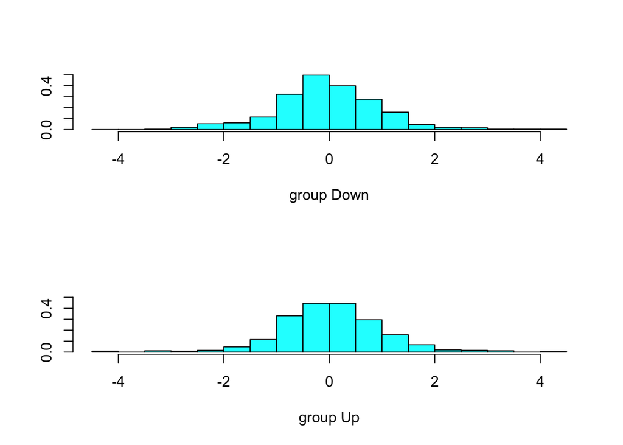

```r
# For each observation in the training set, the `plot` function generates a plot of linear discriminants i.e. sum(coeff * predictor)
plot(lda.fit)
```

## Predicting with LDA The `predict` function returns a list with three elements - `class` contains LDA’s predictions abut the movement of the market - `posterior` is a matrix where the $k^th$ columb contains the posterior probability that the corresponding observation belongs to the $k^th$ class. - `x` contains the linear discriminants as described earlier.

```r
lda.pred <- predict(lda.fit, Smarket.2005)
names(lda.pred)
```

```
## [1] "class"     "posterior" "x"
```

LDA and Logistic Regression predictions are almost identical.

```r
lda.class <- lda.pred$class
table(lda.class, Direction.2005)
```

```
##          Direction.2005
## lda.class Down  Up
##      Down   35  35
##      Up     76 106
```

```r
mean(lda.class == Direction.2005)
```

```
## [1] 0.5595238
```

Appling a 50% threshold to the posterior probabilities allows us to recreate the predictions contained in `lda.pred$class`.

```r
sum(lda.pred$posterior[, 1] >= .5)
```

```
## [1] 70
```

```r
sum(lda.pred$posterior[, 1] < .5)
```

```
## [1] 182
```

The posterior probability outputs by the model correspond t othe probability that the market will **decrease** instead of **increase**, as was the case with logistic regression.

```r
lda.pred$posterior[1:10, 1]   # First 10 probabilities are mostly below 10
```

```
##       999      1000      1001      1002      1003      1004      1005      1006
## 0.4901792 0.4792185 0.4668185 0.4740011 0.4927877 0.4938562 0.4951016 0.4872861
##      1007      1008
## 0.4907013 0.4844026
```

```r
lda.class[1:10]               # First 10 classes all correspond to `Up`
```

```
##  [1] Up Up Up Up Up Up Up Up Up Up
## Levels: Down Up
```

To use a posterior probability other than 50% for binomializing

```r
# If we wish to predict market will decrease with higher certainty
sum(lda.pred$posterior[, 1] > 0.9)
```

```
## [1] 0
```

There were no days in 2005 where the predicted probability of decrease was above 90%. The greatest posterior probability was actually 52.5%.

# Example 03 - Quadratic Discriminant Analysis

## First Model

We will now fit the QDA model to the `Smarket` data using the `qda` function, also part of the `MASS` library.

```r
# Syntax is identical to `lda`
qda.fit <- qda(Direction ~ Lag1 + Lag2, data = Smarket, subset = train.idx)
qda.fit
```

```
## Call:
## qda(Direction ~ Lag1 + Lag2, data = Smarket, subset = train.idx)
##
## Prior probabilities of groups:
##     Down       Up
## 0.491984 0.508016
##
## Group means:
##             Lag1        Lag2
## Down  0.04279022  0.03389409
## Up   -0.03954635 -0.03132544
```

## Initial Observations

- Prior probabilities are the same as before because the dataset hasn’t changed.
- Group means are also the same as before.
- The output does not contain the coefficients of discriminants, though.
- This is because the QDA classifier uses a quadratic, rather than linear, discriminant function.

## Prediction

```r
qda.class <- predict(qda.fit, Smarket.2005)$class
table(qda.class, Direction.2005)
```

```
##          Direction.2005
## qda.class Down  Up
##      Down   30  20
##      Up     81 121
```

```r
mean(qda.class == Direction.2005)
```

```
## [1] 0.5992063
```

## Analysis

- QDA predictions have an accuracy of ~60% even though 2005 data was not used to fit the model.
- This suggests
  - the underlying hypothesis function $f(X)$ is probably non-linear.
  - the classes have different correlations between predictorss.

# Example 04 - Stock Market Data - Naive Bayes

## First Model

We will now fit a Naive Bayes classifier to the `Smarket` data through the `naiveBayes` function call which is part of the `e1071` library.

By default, this implementation models each quantitative feature using a Gaussian distribution. We can, however, use the kernel density estimate variant as well.

```r
nb.fit <- naiveBayes(
  Direction ~ Lag1 + Lag2,
  data = Smarket,
  subset = train.idx
)

nb.fit
```

```
##
## Naive Bayes Classifier for Discrete Predictors
##
## Call:
## naiveBayes.default(x = X, y = Y, laplace = laplace)
##
## A-priori probabilities:
## Y
##     Down       Up
## 0.491984 0.508016
##
## Conditional probabilities:
##       Lag1
## Y             [,1]     [,2]
##   Down  0.04279022 1.227446
##   Up   -0.03954635 1.231668
##
##       Lag2
## Y             [,1]     [,2]
##   Down  0.03389409 1.239191
##   Up   -0.03132544 1.220765
```

The output consists of - the prior probabilities of each class, which are just the proportions of records in training data belonging to each class. - the matrix output for each variable shows the mean and standard deviation for each class. - we can verify this manually.

```r
# Verify the mean of `Lag1` for cases where the marketdown
mean(Smarket$Lag1[train.idx][Smarket$Direction[train.idx] == 'Down'])
```

```
## [1] 0.04279022
```

```r
# Verify the standard deviation of `Lag` for cases where market moves down
sd(Smarket$Lag1[train.idx][Smarket$Direction[train.idx] == 'Down'])
```

```
## [1] 1.227446
```

## Predictions

```r
nb.class <- predict(nb.fit, Smarket.2005)
table(nb.class, Direction.2005)
```

```
##         Direction.2005
## nb.class Down  Up
##     Down   28  20
##     Up     83 121
```

```r
mean(nb.class == Direction.2005)
```

```
## [1] 0.5912698
```

Naive Bayes performs very well on this data with accuracy only slightly lower than QDA but much better than LDA.

We can also use the `predict` function to generate estimates of probability that each observation belongs to a particular class.

```r
nb.preds <- predict(nb.fit, Smarket.2005, type = 'raw')
nb.preds[1:5, ]
```

```
##           Down        Up
## [1,] 0.4873164 0.5126836
## [2,] 0.4762492 0.5237508
## [3,] 0.4653377 0.5346623
## [4,] 0.4748652 0.5251348
## [5,] 0.4901890 0.5098110
```

# Example 05 - Stock Market - K-Nearest Neighbors

## First Model - $K = 1$S

`class::knn` does not follow a fit -> predict process. Instead, it performs predictions with a single command.

```r
# Matrix of training predictors
train.X <- cbind(Smarket$Lag1, Smarket$Lag2)[train.idx, ]
test.X <- cbind(Smarket$Lag1, Smarket$Lag2)[!train.idx, ]

# Vector of targets
train.Direction <- Smarket$Direction[train.idx]

# Seed the random number generator to allow KNN for randomly choosing
# a subset of neighbors for tie-breaking in prediction. The seed will
# ensure results are reproducible.
set.seed(1)
knn.pred <- knn(train.X, test.X, train.Direction, k = 1)  # Based on 1 nearest neigbhor
table(knn.pred, Direction.2005)
```

```
##         Direction.2005
## knn.pred Down Up
##     Down   43 58
##     Up     68 83
```

```r
mean(knn.pred == Direction.2005)
```

```
## [1] 0.5
```

Results with $K = 1$ are not very good because this leads to very high variance and potential for overfitting. Accuracy is only 50%.

### Second Model - $K = 3$

Repeating the process with $K = 3$.

```r
knn.pred <- knn(train.X, test.X, train.Direction, k = 3)
table(knn.pred, Direction.2005)
```

```
##         Direction.2005
## knn.pred Down Up
##     Down   48 54
##     Up     63 87
```

```r
mean(knn.pred == Direction.2005)
```

```
## [1] 0.5357143
```

No significant improvement. QDA is most likely the best model for this dataset.

# Example 06 - `Caravan` - KNN

## Dataset Introduction

KNN didn’t perform well on the `Smarket` data but it can perform well on other datasets where the relationship between the predictors and response is non-linear and where the predictors’ distributions violate assumptions necessary for KNN, or where the ratio of the predictors to number of training examples is very large.

```r
dim(Caravan)                    # 5822 examples, 86 predictors
```

```
## [1] 5822   86
```

```r
summary(Caravan$Purchase)       # Target is categorical
```

```
##   No  Yes
## 5474  348
```

```r
mean(Caravan$Purchase == 'Yes') # 5.98% purchased caravan insurance
```

```
## [1] 0.05977327
```

## Feature Scaling

KNN’s fit can be influenced by the **scale** of the features used. For KNN, if salary is expressed in thousands of dollars but age is expressed in years, then a difference in salary between two data points will skew the distance between neighboring points, and thus the final classification.

The way to deal with this is to standardize or normalize the features with the `scale` function.

```r
standardized.X <- scale(Caravan[, -86])   # Exclude Purchase - the categorical target
c(var(Caravan[, 1]), var(Caravan[, 2]))   # Variance of original features
```

```
## [1] 165.0378474   0.1647078
```

```r
c(var(standardized.X[, 1]), var(standardized.X[, 2])) # Variance of scaled features
```

```
## [1] 1 1
```

## Third Model - Standardized Features, Train-Test Split, $K = 1$

Split the observations into train and test set, with test set consisting of the first 1,000 observations.

```r
# First 1k observations are test, rest are train
test <- 1:1000
train.X <- standardized.X[-test, ]
test.X <- standardized.X[test, ]
train.Y <- Caravan$Purchase[-test]
test.Y <- Caravan$Purchase[test]

# Fit the model
set.seed(1)
knn.pred <- knn(train.X, test.X, train.Y, k = 1)

# Evaluate
mean(test.Y == knn.pred)    # Overall accuracy
```

```
## [1] 0.882
```

```r
mean(test.Y != knn.pred)    # Overall error rate
```

```
## [1] 0.118
```

```r
mean(test.Y != 'No')        # Percentage of records where the label is not 'No'
```

```
## [1] 0.059
```

Accuracy is good, and error rate is low. But of the labels, only 6% customers actually purchased insurance. This means we could get the error rate down to ~6% by **always** predicting `No` regardless of the predictors.

The fraction of individuals that are crrectly predicted to buy Caravan insurance might be a more relevant metric of interest.

```r
table(knn.pred, test.Y)
```

```
##         test.Y
## knn.pred  No Yes
##      No  873  50
##      Yes  68   9
```

## Third Model - Standardized Features, Train-Test Split, $K = 3$

```r
knn.pred <- knn(train.X, test.X, train.Y, k = 3)
table(knn.pred, test.Y)
```

```
##         test.Y
## knn.pred  No Yes
##      No  920  54
##      Yes  21   5
```

With $K = 3$, the success rate on customers who actually purchase insurance is 19.2%.

## Third Model - Standardized Features, Train-Test Split, $K = 5$

```r
knn.pred <- knn(train.X, test.X, train.Y, k = 5)
table(knn.pred, test.Y)
```

```
##         test.Y
## knn.pred  No Yes
##      No  930  55
##      Yes  11   4
```

With $K = 5$, the success rate on customers who actually purchase insurance increases to 26.7%.

## Fourth Model - Logistic Regression with Custom Threshold

If we predict a purchase when the predicted probability exceeds 0.25 instead of 0.50 using a logistic regression model, we can get a better classifier.

```r
glm.fits.caravan.logreg <- glm(
  Purchase ~ .,
  data = Caravan,
  family = binomial,
  subset = -test
)
glm.probs.caravan.logreg <- predict(
  glm.fits.caravan.logreg, Caravan[test, ], type = 'response'
)

# Examine error rate with 0.5 as the binomializing threshold
glm.pred.caravan.logreg <- rep("No", 1000)
glm.pred.caravan.logreg[glm.probs.caravan.logreg > 0.5] <- "Yes"
table(glm.pred.caravan.logreg, test.Y)
```

```
##                        test.Y
## glm.pred.caravan.logreg  No Yes
##                     No  934  59
##                     Yes   7   0
```

```r
# Examine error rate with 0.25 as the binomializing threshold
glm.pred.caravan.logreg <- rep("No", 1000)
glm.pred.caravan.logreg[glm.probs.caravan.logreg > 0.25] <- "Yes"
table(glm.pred.caravan.logreg, test.Y)
```

```
##                        test.Y
## glm.pred.caravan.logreg  No Yes
##                     No  919  48
##                     Yes  22  11
```

In the first case with threshold = 0.5, the classifier predicts 7 insurance purchases and all of them are wrong.

So using a different classification threshold can often be useful.

# Example 07 - `Bikeshare` - Poisson Regression

In this example, we will use Poisson Regression to predict the number of bike rentals per hour in Washington, DC using the `Bikeshare` dataset.

```r
head(Bikeshare)
```

```
##   season mnth day hr holiday weekday workingday   weathersit temp  atemp  hum
## 1      1  Jan   1  0       0       6          0        clear 0.24 0.2879 0.81
## 2      1  Jan   1  1       0       6          0        clear 0.22 0.2727 0.80
## 3      1  Jan   1  2       0       6          0        clear 0.22 0.2727 0.80
## 4      1  Jan   1  3       0       6          0        clear 0.24 0.2879 0.75
## 5      1  Jan   1  4       0       6          0        clear 0.24 0.2879 0.75
## 6      1  Jan   1  5       0       6          0 cloudy/misty 0.24 0.2576 0.75
##   windspeed casual registered bikers
## 1    0.0000      3         13     16
## 2    0.0000      8         32     40
## 3    0.0000      5         27     32
## 4    0.0000      3         10     13
## 5    0.0000      0          1      1
## 6    0.0896      0          1      1
```

```r
dim(Bikeshare)
```

```
## [1] 8645   15
```

```r
names(Bikeshare)
```

```
##  [1] "season"     "mnth"       "day"        "hr"         "holiday"
##  [6] "weekday"    "workingday" "weathersit" "temp"       "atemp"
## [11] "hum"        "windspeed"  "casual"     "registered" "bikers"
```

## Model 01 - Least Squares Linear Regression

### Coding Scheme 01

```r
mod.bike.lm <- lm(
  bikers ~ mnth + hr + workingday + temp + weathersit,
  data = Bikeshare
)

summary(mod.bike.lm)
```

```
##
## Call:
## lm(formula = bikers ~ mnth + hr + workingday + temp + weathersit,
##     data = Bikeshare)
##
## Residuals:
##     Min      1Q  Median      3Q     Max
## -299.00  -45.70   -6.23   41.08  425.29
##
## Coefficients:
##                           Estimate Std. Error t value Pr(>|t|)
## (Intercept)                -68.632      5.307 -12.932  < 2e-16 ***
## mnthFeb                      6.845      4.287   1.597 0.110398
## mnthMarch                   16.551      4.301   3.848 0.000120 ***
## mnthApril                   41.425      4.972   8.331  < 2e-16 ***
## mnthMay                     72.557      5.641  12.862  < 2e-16 ***
## mnthJune                    67.819      6.544  10.364  < 2e-16 ***
## mnthJuly                    45.324      7.081   6.401 1.63e-10 ***
## mnthAug                     53.243      6.640   8.019 1.21e-15 ***
## mnthSept                    66.678      5.925  11.254  < 2e-16 ***
## mnthOct                     75.834      4.950  15.319  < 2e-16 ***
## mnthNov                     60.310      4.610  13.083  < 2e-16 ***
## mnthDec                     46.458      4.271  10.878  < 2e-16 ***
## hr1                        -14.579      5.699  -2.558 0.010536 *
## hr2                        -21.579      5.733  -3.764 0.000168 ***
## hr3                        -31.141      5.778  -5.389 7.26e-08 ***
## hr4                        -36.908      5.802  -6.361 2.11e-10 ***
## hr5                        -24.135      5.737  -4.207 2.61e-05 ***
## hr6                         20.600      5.704   3.612 0.000306 ***
## hr7                        120.093      5.693  21.095  < 2e-16 ***
## hr8                        223.662      5.690  39.310  < 2e-16 ***
## hr9                        120.582      5.693  21.182  < 2e-16 ***
## hr10                        83.801      5.705  14.689  < 2e-16 ***
## hr11                       105.423      5.722  18.424  < 2e-16 ***
## hr12                       137.284      5.740  23.916  < 2e-16 ***
## hr13                       136.036      5.760  23.617  < 2e-16 ***
## hr14                       126.636      5.776  21.923  < 2e-16 ***
## hr15                       132.087      5.780  22.852  < 2e-16 ***
## hr16                       178.521      5.772  30.927  < 2e-16 ***
## hr17                       296.267      5.749  51.537  < 2e-16 ***
## hr18                       269.441      5.736  46.976  < 2e-16 ***
## hr19                       186.256      5.714  32.596  < 2e-16 ***
## hr20                       125.549      5.704  22.012  < 2e-16 ***
## hr21                        87.554      5.693  15.378  < 2e-16 ***
## hr22                        59.123      5.689  10.392  < 2e-16 ***
## hr23                        26.838      5.688   4.719 2.41e-06 ***
## workingday                   1.270      1.784   0.711 0.476810
## temp                       157.209     10.261  15.321  < 2e-16 ***
## weathersitcloudy/misty     -12.890      1.964  -6.562 5.60e-11 ***
## weathersitlight rain/snow  -66.494      2.965 -22.425  < 2e-16 ***
## weathersitheavy rain/snow -109.745     76.667  -1.431 0.152341
## ---
## Signif. codes:  0 '***' 0.001 '**' 0.01 '*' 0.05 '.' 0.1 ' ' 1
##
## Residual standard error: 76.5 on 8605 degrees of freedom
## Multiple R-squared:  0.6745, Adjusted R-squared:  0.6731
## F-statistic: 457.3 on 39 and 8605 DF,  p-value: < 2.2e-16
```

In this coding, the first level of `hr` and `mnth` are not provided explicit coefficients. Instead they are assumed as part of the baseline, and all other coefficients are measured relative to this baseline.

`mnthFeb` coefficient being 6.845 signifies that holding all other variables constant, there are, on average, about 7 additional riders in Feburary **relative to January**.

### Coding Scheme 02

We now create a different model that uses a different coding for the categorical variables.

```r
contrasts(Bikeshare$hr) <- contr.sum(24)
contrasts(Bikeshare$mnth) <- contr.sum(12)

mod.bike.lm.contrasts <- lm(
  bikers ~ mnth + hr + workingday + temp + weathersit,
  data = Bikeshare
)
summary(mod.bike.lm.contrasts)
```

```
##
## Call:
## lm(formula = bikers ~ mnth + hr + workingday + temp + weathersit,
##     data = Bikeshare)
##
## Residuals:
##     Min      1Q  Median      3Q     Max
## -299.00  -45.70   -6.23   41.08  425.29
##
## Coefficients:
##                            Estimate Std. Error t value Pr(>|t|)
## (Intercept)                 73.5974     5.1322  14.340  < 2e-16 ***
## mnth1                      -46.0871     4.0855 -11.281  < 2e-16 ***
## mnth2                      -39.2419     3.5391 -11.088  < 2e-16 ***
## mnth3                      -29.5357     3.1552  -9.361  < 2e-16 ***
## mnth4                       -4.6622     2.7406  -1.701  0.08895 .
## mnth5                       26.4700     2.8508   9.285  < 2e-16 ***
## mnth6                       21.7317     3.4651   6.272 3.75e-10 ***
## mnth7                       -0.7626     3.9084  -0.195  0.84530
## mnth8                        7.1560     3.5347   2.024  0.04295 *
## mnth9                       20.5912     3.0456   6.761 1.46e-11 ***
## mnth10                      29.7472     2.6995  11.019  < 2e-16 ***
## mnth11                      14.2229     2.8604   4.972 6.74e-07 ***
## hr1                        -96.1420     3.9554 -24.307  < 2e-16 ***
## hr2                       -110.7213     3.9662 -27.916  < 2e-16 ***
## hr3                       -117.7212     4.0165 -29.310  < 2e-16 ***
## hr4                       -127.2828     4.0808 -31.191  < 2e-16 ***
## hr5                       -133.0495     4.1168 -32.319  < 2e-16 ***
## hr6                       -120.2775     4.0370 -29.794  < 2e-16 ***
## hr7                        -75.5424     3.9916 -18.925  < 2e-16 ***
## hr8                         23.9511     3.9686   6.035 1.65e-09 ***
## hr9                        127.5199     3.9500  32.284  < 2e-16 ***
## hr10                        24.4399     3.9360   6.209 5.57e-10 ***
## hr11                       -12.3407     3.9361  -3.135  0.00172 **
## hr12                         9.2814     3.9447   2.353  0.01865 *
## hr13                        41.1417     3.9571  10.397  < 2e-16 ***
## hr14                        39.8939     3.9750  10.036  < 2e-16 ***
## hr15                        30.4940     3.9910   7.641 2.39e-14 ***
## hr16                        35.9445     3.9949   8.998  < 2e-16 ***
## hr17                        82.3786     3.9883  20.655  < 2e-16 ***
## hr18                       200.1249     3.9638  50.488  < 2e-16 ***
## hr19                       173.2989     3.9561  43.806  < 2e-16 ***
## hr20                        90.1138     3.9400  22.872  < 2e-16 ***
## hr21                        29.4071     3.9362   7.471 8.74e-14 ***
## hr22                        -8.5883     3.9332  -2.184  0.02902 *
## hr23                       -37.0194     3.9344  -9.409  < 2e-16 ***
## workingday                   1.2696     1.7845   0.711  0.47681
## temp                       157.2094    10.2612  15.321  < 2e-16 ***
## weathersitcloudy/misty     -12.8903     1.9643  -6.562 5.60e-11 ***
## weathersitlight rain/snow  -66.4944     2.9652 -22.425  < 2e-16 ***
## weathersitheavy rain/snow -109.7446    76.6674  -1.431  0.15234
## ---
## Signif. codes:  0 '***' 0.001 '**' 0.01 '*' 0.05 '.' 0.1 ' ' 1
##
## Residual standard error: 76.5 on 8605 degrees of freedom
## Multiple R-squared:  0.6745, Adjusted R-squared:  0.6731
## F-statistic: 457.3 on 39 and 8605 DF,  p-value: < 2.2e-16
```

The difference between these codings is that in `mod.bike.lm.contrasts` results in a coefficient being reported for all levels of `hr` and `mnth`.

The coefficients for the last level of `mnth` and `hr` are not zero, rather they’re equal to $-1 \times$ `sum`(coefficient estimates of other levels).

This, in turn, means coefficients of `hr` and `math` in `mod.bike.lm.contrasts` will always sum to 0, and the coefficient of `mnth1` being -46.0871 means there are 46 fewer rides in January relative to the **yearly average**.

### Predictions are Coding Agnostc

The predictions from the two models will be the same, regardless of the coding scheme used. Coding scheme only affects interpretation of coefficients, not predictions.

```r
# Sum of squared error between the predictions from both models
sum((predict(mod.bike.lm) - predict(mod.bike.lm.contrasts))^2)
```

```
## [1] 1.426274e-18
```

```r
# Another way to test this
all.equal(predict(mod.bike.lm), predict(mod.bike.lm.contrasts))
```

```
## [1] TRUE
```

### Generating Coefficient Plots

For categorical variables like `mnth` and `hr` which have a lot of levels, we can plot the coefficients rather than read them in a table.

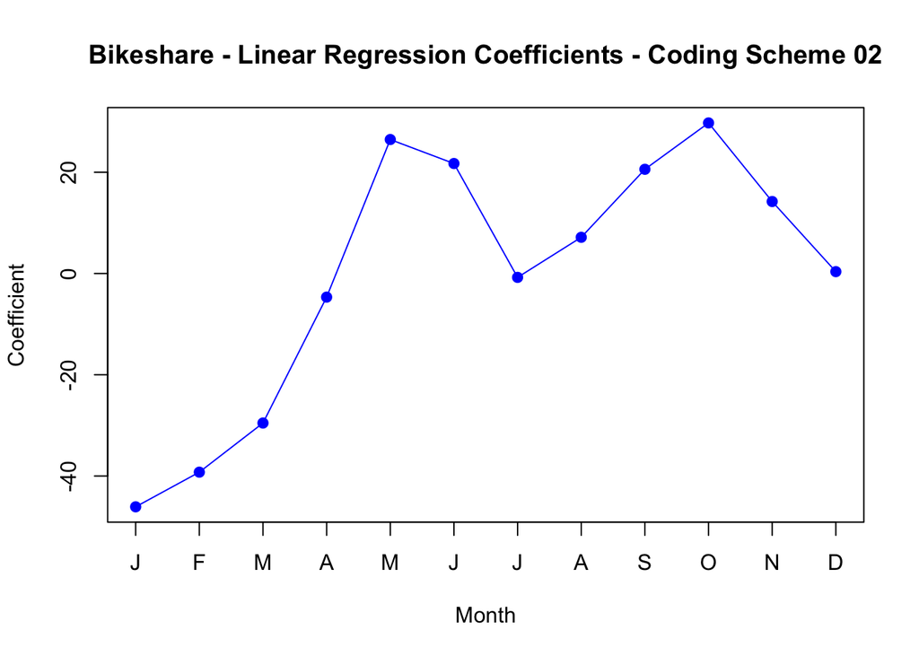

```r
# Because coefficients in this coding scheme used a sum transformation
coef.months <- c(coef(mod.bike.lm.contrasts))[2:12]
coef.months <- c(coef.months, -1 * sum(coef.months))
plot(
  coef.months, xlab = 'Month', ylab = 'Coefficient', xaxt = 'n', col = 'blue',
  pch = 19, type = 'o',
  main = 'Bikeshare - Linear Regression Coefficients - Coding Scheme 02'
)
axis(side = 1, at = 1:12, labels = c('J', 'F', 'M', 'A', 'M', 'J', 'J', 'A', 'S', 'O', 'N', 'D'))
```

We can do the same for `hr`

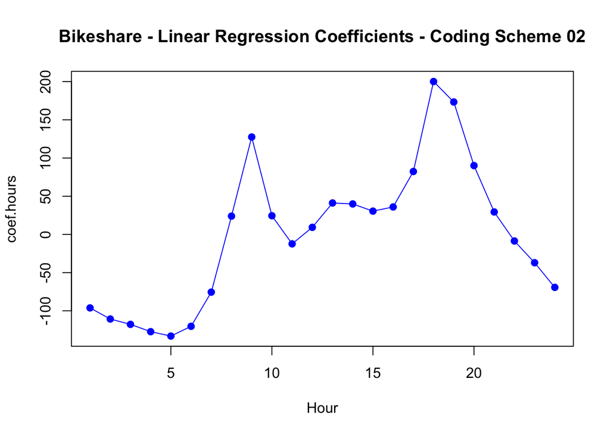

```r
coef.hours <- c(coef(mod.bike.lm.contrasts))[13:35]
coef.hours <- c(coef.hours, - 1 * sum(coef.hours))
plot(coef.hours, xlab = 'Hour', ylabel = 'Coefficient', col = 'blue', pch = 19,
     type = 'o', main = 'Bikeshare - Linear Regression Coefficients - Coding Scheme 02')
```

## Model 02 - Poisson Regression

### Fitting Model

Instead of fitting a linear regressor, we use a Poisson regressor.

```r
mod.bike.pois <- glm(
  bikers ~ mnth + hr + workingday + temp + weathersit,
  data = Bikeshare,
  family  = poisson
)

summary(mod.bike.pois)
```

```
##
## Call:
## glm(formula = bikers ~ mnth + hr + workingday + temp + weathersit,
##     family = poisson, data = Bikeshare)
##
## Deviance Residuals:
##      Min        1Q    Median        3Q       Max
## -20.7574   -3.3441   -0.6549    2.6999   21.9628
##
## Coefficients:
##                            Estimate Std. Error  z value Pr(>|z|)
## (Intercept)                4.118245   0.006021  683.964  < 2e-16 ***
## mnth1                     -0.670170   0.005907 -113.445  < 2e-16 ***
## mnth2                     -0.444124   0.004860  -91.379  < 2e-16 ***
## mnth3                     -0.293733   0.004144  -70.886  < 2e-16 ***
## mnth4                      0.021523   0.003125    6.888 5.66e-12 ***
## mnth5                      0.240471   0.002916   82.462  < 2e-16 ***
## mnth6                      0.223235   0.003554   62.818  < 2e-16 ***
## mnth7                      0.103617   0.004125   25.121  < 2e-16 ***
## mnth8                      0.151171   0.003662   41.281  < 2e-16 ***
## mnth9                      0.233493   0.003102   75.281  < 2e-16 ***
## mnth10                     0.267573   0.002785   96.091  < 2e-16 ***
## mnth11                     0.150264   0.003180   47.248  < 2e-16 ***
## hr1                       -0.754386   0.007879  -95.744  < 2e-16 ***
## hr2                       -1.225979   0.009953 -123.173  < 2e-16 ***
## hr3                       -1.563147   0.011869 -131.702  < 2e-16 ***
## hr4                       -2.198304   0.016424 -133.846  < 2e-16 ***
## hr5                       -2.830484   0.022538 -125.586  < 2e-16 ***
## hr6                       -1.814657   0.013464 -134.775  < 2e-16 ***
## hr7                       -0.429888   0.006896  -62.341  < 2e-16 ***
## hr8                        0.575181   0.004406  130.544  < 2e-16 ***
## hr9                        1.076927   0.003563  302.220  < 2e-16 ***
## hr10                       0.581769   0.004286  135.727  < 2e-16 ***
## hr11                       0.336852   0.004720   71.372  < 2e-16 ***
## hr12                       0.494121   0.004392  112.494  < 2e-16 ***
## hr13                       0.679642   0.004069  167.040  < 2e-16 ***
## hr14                       0.673565   0.004089  164.722  < 2e-16 ***
## hr15                       0.624910   0.004178  149.570  < 2e-16 ***
## hr16                       0.653763   0.004132  158.205  < 2e-16 ***
## hr17                       0.874301   0.003784  231.040  < 2e-16 ***
## hr18                       1.294635   0.003254  397.848  < 2e-16 ***
## hr19                       1.212281   0.003321  365.084  < 2e-16 ***
## hr20                       0.914022   0.003700  247.065  < 2e-16 ***
## hr21                       0.616201   0.004191  147.045  < 2e-16 ***
## hr22                       0.364181   0.004659   78.173  < 2e-16 ***
## hr23                       0.117493   0.005225   22.488  < 2e-16 ***
## workingday                 0.014665   0.001955    7.502 6.27e-14 ***
## temp                       0.785292   0.011475   68.434  < 2e-16 ***
## weathersitcloudy/misty    -0.075231   0.002179  -34.528  < 2e-16 ***
## weathersitlight rain/snow -0.575800   0.004058 -141.905  < 2e-16 ***
## weathersitheavy rain/snow -0.926287   0.166782   -5.554 2.79e-08 ***
## ---
## Signif. codes:  0 '***' 0.001 '**' 0.01 '*' 0.05 '.' 0.1 ' ' 1
##
## (Dispersion parameter for poisson family taken to be 1)
##
##     Null deviance: 1052921  on 8644  degrees of freedom
## Residual deviance:  228041  on 8605  degrees of freedom
## AIC: 281159
##
## Number of Fisher Scoring iterations: 5
```

### Generating plots of coefficients

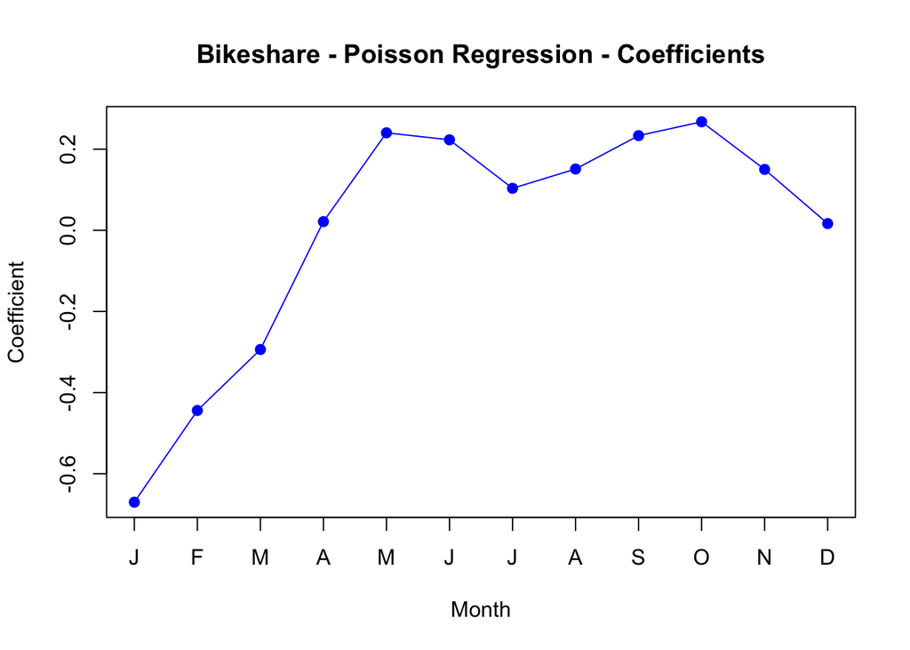

```r
# In this coding, we concatenate the coefficients and their negative sum
coef.month.pois <- coef(mod.bike.pois)[2:12]
coef.month.pois <- c(coef.month.pois, -1 * sum(coef.month.pois))

# Month Coefficients
plot(coef.month.pois, xlab = 'Month', ylab = 'Coefficient', xaxt = 'n', col = 'blue', pch = 19, type = 'o', main = 'Bikeshare - Poisson Regression - Coefficients')
axis(side = 1, at = 1:12, labels = c('J', 'F', 'M', 'A', 'M', 'J', 'J', 'A', 'S', 'O', 'N', 'D'))
```

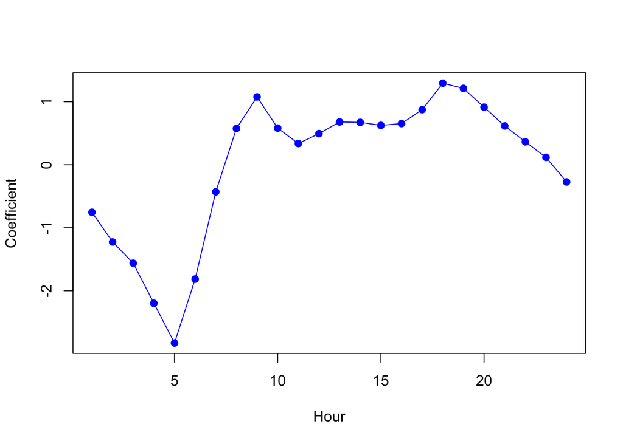

```r
# Hour Coefficients
coef.hours.pois <- coef(mod.bike.pois)[13:35]
coef.hours.pois <- c(coef.hours.pois, -1 * sum(coef.hours.pois))
plot(coef.hours.pois, xlab = 'Hour', ylab = 'Coefficient', col = 'blue', pch = 19, type = 'o')
```

### Predictions

We have to use `type = 'response'` to specify `R` to output
$$exp(\hat\beta_0 + \hat\beta_1X_1 + ... \hat\beta_pX_p)$$
instead of just
$$\hat\beta_0 + \hat\beta_1X_1 + ... \hat\beta_pX_p$$

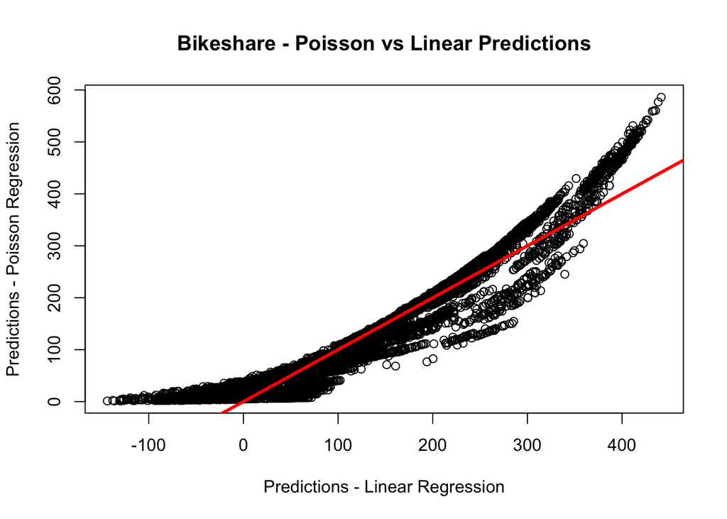

```r
plot(
  predict(mod.bike.lm.contrasts),
  predict(mod.bike.pois, type = 'response'),
  xlab = 'Predictions - Linear Regression',
  ylab = 'Predictions - Poisson Regression',
  main = 'Bikeshare - Poisson vs Linear Predictions'
)
abline(0, 1, col = 2, lwd = 3)
```

### Observations

- Predictions from both models are correlated.
- Poisson regression predictions are **always** non-negative.
- Linear regression predictions can still be negative.
- At very high or low levels of ridership, poisson regression predictions tend to be larger than linear regression.